# Validation: fixated vs. analyzeeyedry on C1L1.asc

Auto-generated validation report

2026-04-08

# 1. Introduction

This document validates the **fixated** R package by comparing its eye-movement measure computations against the **analyzeeyedry** R package, which implements the exact algorithms from the classic **eyedry** program (Clifton, 1990) as used with the UMass EyeTrack software.

The test data is `C1L1.asc`, a single-subject EyeLink ASC file recorded with the UMass EyeTrack 6 software. The file contains Spanish reading data.

## Key format differences in C1L1.asc versus a standard EyeLink file

| Feature | C1L1.asc (UMass EyeTrack) | Standard EyeLink/OpenSesame |
| --- | --- | --- |
| Trial ID format | `TRIALID P100I8D0` (`[prefix][cond]I[item]D[n]`) | `TRIAL 1 ITEM 8 WORD 1 …` |
| Region messages | `REGION CHAR <idx> <line> <char> <xl> <yt> <xr> <yb>` | `TRIAL … WORD … RIGHT_BOUNDARY …` |
| Display onset | `SYNCTIME` (no payload; timestamp is the onset) | `DISPLAY ON` / `t_display_on` in trial_db |
| Trial end | `TRIAL_RESULT <code>` | `stop_trial` MSG |
| Non-ASCII chars | Replaced by spaces in character list | Full Unicode (EDF → ASC) |
| Eye recorded | Right eye only | Configurable |

## Analysis regions

Both algorithms treat **every word as one analysis region**. Word boundaries are derived from the `REGION CHAR` messages: a new word starts at the first character of the sentence and at every non-space character that immediately follows a space.

# 2. Setup

```r
# Install packages from local source if not already available
# Paths are relative to the Rmd's working directory (validation/)
pkg_root       <- file.path(getwd(), "..")          # fixated package root
analyzeeyedry_dir <- file.path(getwd(), "analyzeeyedry")

if (!requireNamespace("analyzeeyedry", quietly = TRUE)) {
  install.packages(analyzeeyedry_dir, repos = NULL, type = "source")
}

devtools::load_all(pkg_root)  # Load fixated functions without installing
if (!requireNamespace("fixated", quietly = TRUE)) {
  install.packages(pkg_root, repos = NULL, type = "source")
}

library(analyzeeyedry)
library(fixated)
library(dplyr)
library(ggplot2)
library(tidyr)
library(knitr)

ASC_FILE <- file.path(pkg_root, "data_to_incorporate", "C1L1.asc")
stopifnot(file.exists(ASC_FILE))
cat("ASC file:", ASC_FILE, "\n")
```

```
## ASC file: /home/rstudio/projects/fixated/validation/../data_to_incorporate/C1L1.asc
```

# 3. Custom parsing helpers for C1L1.asc

Because `C1L1.asc` uses the UMass EyeTrack message format, neither package reads it “out of the box” without configuration. The helper functions below extract all needed data directly from the file and create a tidy `trial_list` that both analyses can work from.

```r
# ---------------------------------------------------------------------------
# Low-level parser: read C1L1.asc into a list of trial objects.
# Each trial contains:
#   $trial_id, $prefix, $cond, $item, $seq
#   $synctime   – absolute timestamp of SYNCTIME (display onset)
#   $chars      – data.frame(idx, char, x_left, y_top, x_right, y_bottom)
#   $fixations  – data.frame(t_start, t_end, duration, x, y)
# ---------------------------------------------------------------------------
parse_c1l1 <- function(filepath, trial_pattern = "^[A-Za-z]") {
  lines <- readLines(filepath, warn = FALSE)

  trial_list <- list()
  in_trial   <- FALSE
  seq_n      <- 0L

  # per-trial accumulators
  cond <- NA_integer_; item <- NA_integer_; tid <- ""
  prefix <- ""; synctime <- NA_real_
  chars_list <- list(); fix_list <- list()

  for (line in lines) {
    # ---- TRIALID ----
    if (grepl("MSG\\s.*TRIALID\\s+(\\S+)", line)) {
      m_tid <- regmatches(line, regexpr("TRIALID\\s+(\\S+)", line))
      if (length(m_tid) > 0L) {
        trial_id <- sub("TRIALID\\s+", "", m_tid)
        if (grepl(trial_pattern, trial_id)) {
          m <- regmatches(trial_id, regexpr("^([A-Za-z]+)(\\d+)[A-Za-z](\\d+)", trial_id))
          if (length(m) > 0L) {
            nums <- regmatches(m, gregexpr("\\d+", m))[[1L]]
            pfx  <- regmatches(m, gregexpr("[A-Za-z]+", m))[[1L]][1L]
            if (length(nums) >= 2L) {
              seq_n      <- seq_n + 1L
              cond       <- as.integer(nums[1L])
              item       <- as.integer(nums[2L])
              tid        <- trial_id
              prefix     <- pfx
              synctime   <- NA_real_
              chars_list <- list()
              fix_list   <- list()
              in_trial   <- TRUE
            }
          }
        } else {
          in_trial <- FALSE
        }
      }
      next
    }

    if (!in_trial) next

    # ---- REGION CHAR ----
    if (grepl("REGION CHAR", line)) {
      parts <- strsplit(trimws(line), "\\s+")[[1L]]
      np    <- length(parts)
      if (np >= 10L) {
        idx   <- as.integer(parts[5L])
        ch    <- if (np >= 11L) parts[7L] else " "
        x_l   <- as.numeric(parts[np - 3L])
        y_t   <- as.numeric(parts[np - 2L])
        x_r   <- as.numeric(parts[np - 1L])
        y_b   <- as.numeric(parts[np])
        chars_list[[length(chars_list) + 1L]] <-
          data.frame(idx = idx, char = ch,
                     x_left = x_l, y_top = y_t,
                     x_right = x_r, y_bottom = y_b,
                     stringsAsFactors = FALSE)
      }
      next
    }

    # ---- SYNCTIME ----
    if (grepl("SYNCTIME", line)) {
      # Format: MSG <timestamp> SYNCTIME
      parts <- strsplit(trimws(line), "\\s+")[[1L]]
      if (length(parts) >= 2L)
        synctime <- as.numeric(parts[2L])
      next
    }

    # ---- EFIX R ----
    if (grepl("^EFIX\\s+R", line)) {
      parts <- strsplit(trimws(line), "\\s+")[[1L]]
      # EFIX R t_start t_end duration x y pupil
      if (length(parts) >= 7L) {
        fix_list[[length(fix_list) + 1L]] <- data.frame(
          t_start  = as.numeric(parts[3L]),
          t_end    = as.numeric(parts[4L]),
          duration = as.numeric(parts[5L]),
          x        = as.numeric(parts[6L]),
          y        = as.numeric(parts[7L]),
          stringsAsFactors = FALSE
        )
      }
      next
    }

    # ---- TRIAL_RESULT ----
    if (grepl("TRIAL_RESULT", line)) {
      if (in_trial && length(chars_list) > 0L) {
        chars_df <- do.call(rbind, chars_list)
        chars_df <- chars_df[order(chars_df$idx), ]
        fix_df   <- if (length(fix_list) > 0L)
                      do.call(rbind, fix_list)
                    else
                      data.frame(t_start = numeric(), t_end = numeric(),
                                 duration = numeric(), x = numeric(), y = numeric())
        trial_list[[length(trial_list) + 1L]] <- list(
          trial_id = tid, prefix = prefix,
          cond = cond, item = item, seq = seq_n,
          synctime = synctime,
          chars    = chars_df,
          fixations = fix_df
        )
      }
      in_trial <- FALSE
      next
    }
  }
  trial_list
}


# ---------------------------------------------------------------------------
# Build pixel-space word ROIs from the chars data frame.
# Word starts are determined by the space-detection rule (same as analyzeeyedry).
# The space between two words is included in the PRECEDING word's x_end
# (matching analyzeeyedry's region convention).
# ---------------------------------------------------------------------------
build_word_rois <- function(chars_df) {
  n <- nrow(chars_df)
  if (n == 0L) return(data.frame())

  # Detect word starts: first char, and any non-space after a space
  word_start_char_idx <- integer(0)
  for (ci in seq_len(n)) {
    if (ci == 1L) {
      word_start_char_idx <- c(word_start_char_idx, ci)
    } else if (chars_df$char[ci - 1L] == " " && chars_df$char[ci] != " ") {
      word_start_char_idx <- c(word_start_char_idx, ci)
    }
  }

  nw <- length(word_start_char_idx)
  if (nw == 0L) return(data.frame())

  # Word end (in the chars_df row index) = one before next word start
  word_end_char_idx <- c(word_start_char_idx[-1L] - 1L, n)

  rois <- vector("list", nw)
  for (w in seq_len(nw)) {
    rows   <- word_start_char_idx[w]:word_end_char_idx[w]
    x_s    <- chars_df$x_left[word_start_char_idx[w]]
    x_e    <- chars_df$x_right[word_end_char_idx[w]]
    y_s    <- min(chars_df$y_top[rows])
    y_e    <- max(chars_df$y_bottom[rows])
    # Reconstruct word text (spaces are either literal or non-ASCII placeholders)
    word_str <- paste(chars_df$char[word_start_char_idx[w]:
                                      word_end_char_idx[w]], collapse = "")
    rois[[w]] <- data.frame(
      word_id = w, word = word_str,
      x_start = x_s, x_end = x_e,
      y_start = y_s, y_end = y_e,
      char_start_idx = chars_df$idx[word_start_char_idx[w]],
      char_end_idx   = chars_df$idx[word_end_char_idx[w]],
      stringsAsFactors = FALSE
    )
  }
  do.call(rbind, rois)
}


# ---------------------------------------------------------------------------
# Parse the whole file and attach word ROIs to every trial.
# ---------------------------------------------------------------------------
trial_list <- parse_c1l1(ASC_FILE)
for (ti in seq_along(trial_list)) {
  trial_list[[ti]]$word_rois <- build_word_rois(trial_list[[ti]]$chars)
}

cat(sprintf("Parsed %d trials\n", length(trial_list)))
```

```
## Parsed 175 trials
```

```r
prefix_table <- table(sapply(trial_list, `[[`, "prefix"))
print(prefix_table)
```

```
##
##   E   F   P
## 130  34  11
```

# 4. analyzeeyedry analysis

`analyzeeyedry` converts pixel coordinates to 0-indexed **character positions** using the `REGION CHAR` messages and expresses fixation times relative to `SYNCTIME`. The package-level functions `asc_to_fixations()` and `asc_to_cnt()` do this automatically.

```r
# Build word regions (char-index space) from the ASC file
word_regions_edry <- asc_to_cnt(
  ASC_FILE,
  trial_pattern  = "^[A-Za-z]",
  spillover_gap  = 1L,
  spillover_size = 20L
)
cat(sprintf("Word regions: %d trial × cond combinations\n", nrow(word_regions_edry)))
```

```
## Word regions: 175 trial × cond combinations
```

```r
cat(sprintf("Max regions per trial: %d\n",
            max(word_regions_edry$nreg, na.rm = TRUE)))
```

```
## Max regions per trial: 23
```

```r
# Extract character-indexed fixations
fix_edry <- asc_to_fixations(
  ASC_FILE,
  subj          = 1L,
  trial_pattern = "^[A-Za-z]"
)
cat(sprintf("Fixations extracted: %d\n", nrow(fix_edry)))
```

```
## Fixations extracted: 2572
```

```r
# Assign fixations to word regions
fix_edry_r <- assign_regions_to_fixations(fix_edry, word_regions_edry)

# Compute all eyedry measures
# shorttime = 80 ms: ignore fixations <= 80 ms
# longtime  = 800 ms: discard region if a fixation > 800 ms is encountered
nregmax_val <- max(word_regions_edry$nreg, na.rm = TRUE)
measures_edry <- compute_fixation_measures(
  fix_edry_r,
  word_regions_edry,
  shorttime = 80L,
  longtime  = 800L,
  nregmax   = nregmax_val
)
cat(sprintf("Measures computed for %d trials\n", nrow(measures_edry)))
```

```
## Measures computed for 175 trials
```

```r
head(measures_edry[, 1:14])
```

| subj | item | cond | seq | ff_R1 | ff_R2 | ff_R3 | ff_R4 | ff_R5 | ff_R6 | ff_R7 | ff_R8 | ff_R9 | ff_R10 |
| --- | --- | --- | --- | --- | --- | --- | --- | --- | --- | --- | --- | --- | --- |
| 1 | 8 | 100 | 1 | 123 | NA | NA | NA | NA | NA | 210 | 199 | 168 | NA |
| 1 | 3 | 100 | 2 | NA | 215 | 207 | NA | 239 | 169 | 186 | 156 | 240 | NA |
| 1 | 3 | 200 | 3 | NA | NA | NA | 128 | 187 | NA | NA | NA | NA | NA |
| 1 | 2 | 100 | 4 | 192 | NA | NA | NA | NA | NA | NA | NA | NA | 159 |
| 1 | 2 | 200 | 5 | NA | NA | 166 | NA | 186 | NA | NA | NA | NA | NA |
| 1 | 5 | 100 | 6 | 212 | 196 | 173 | NA | 284 | NA | NA | 291 | NA | NA |

# 5. fixated analysis

`fixated::compute_eye_measures()` works in **pixel coordinates**. We feed it the fixations and word ROIs derived from the same `REGION CHAR` messages.

Two additional alignment decisions must be made explicit:

1. **Display-onset filter**: `analyzeeyedry` skips fixations that end before `SYNCTIME` and truncates fixations that *straddle* the onset (setting the relative start time to 0). `fixated` with a `trial_db` filter uses `start_time > t_display_on` (strict), which **excludes** straddling fixations. We test both approaches and discuss the difference.
2. **Duration filtering**: `analyzeeyedry` skips fixations ≤ 80 ms and discards regions when a fixation > 800 ms occurs. `fixated` has no built-in duration cutoffs. We show results with and without matching the eyedry cutoffs applied upstream.

```r
# -------------------------------------------------------------------------
# Build a tidy fixations tibble and a tidy ROI tibble for fixated,
# applying the SYNCTIME (display-onset) filter to mirror analyzeeyedry.
# -------------------------------------------------------------------------
build_fixated_inputs <- function(tl,
                                 onset_filter = c("synctime_strict",
                                                  "synctime_truncate",
                                                  "none")) {
  onset_filter <- match.arg(onset_filter)

  fix_rows <- list()
  roi_rows <- list()

  for (ti in seq_along(tl)) {
    tr     <- tl[[ti]]
    trial_nr <- ti
    cond_v   <- tr$cond
    item_v   <- tr$item
    fix_df   <- tr$fixations
    rois     <- tr$word_rois

    if (nrow(fix_df) == 0L || nrow(rois) == 0L) next

    synctime_val <- tr$synctime

    # Apply onset filter
    if (onset_filter == "synctime_strict" && !is.na(synctime_val)) {
      # Include only fixations that STARTED after display onset
      fix_df <- fix_df[fix_df$t_start > synctime_val, , drop = FALSE]
    } else if (onset_filter == "synctime_truncate" && !is.na(synctime_val)) {
      # Truncate fixations that straddle onset (matching analyzeeyedry)
      fix_df <- fix_df[fix_df$t_end > synctime_val, , drop = FALSE]
      straddle <- !is.na(fix_df$t_start) & fix_df$t_start <= synctime_val
      if (any(straddle)) {
        # Truncate: adjust start_time and recalculate duration
        fix_df$t_start[straddle]  <- synctime_val
        fix_df$duration[straddle] <- fix_df$t_end[straddle] -
                                     fix_df$t_start[straddle]
      }
    }

    if (nrow(fix_df) == 0L) next

    # Build fixation rows
    for (fi in seq_len(nrow(fix_df))) {
      fix_rows[[length(fix_rows) + 1L]] <- data.frame(
        trial_nr   = trial_nr,
        cond       = cond_v,
        item       = item_v,
        start_time = fix_df$t_start[fi],
        end_time   = fix_df$t_end[fi],
        duration   = fix_df$duration[fi],
        avg_x      = fix_df$x[fi],
        avg_y      = fix_df$y[fi],
        stringsAsFactors = FALSE
      )
    }

    # Build ROI rows
    rois$trial_nr <- trial_nr
    rois$cond     <- cond_v
    rois$item     <- item_v
    roi_rows[[length(roi_rows) + 1L]] <- rois
  }

  fix_tbl <- if (length(fix_rows) > 0L)
               dplyr::as_tibble(do.call(rbind, fix_rows))
             else
               dplyr::tibble()
  roi_tbl <- if (length(roi_rows) > 0L)
               dplyr::as_tibble(do.call(rbind, roi_rows))
             else
               dplyr::tibble()

  list(fixations = fix_tbl, roi = roi_tbl)
}


# ---- Version A: synctime_strict (start_time > SYNCTIME) ----
inp_strict <- build_fixated_inputs(trial_list, onset_filter = "synctime_strict")
cat("Fixated (strict SYNCTIME filter):",
    nrow(inp_strict$fixations), "fixations across",
    n_distinct(inp_strict$fixations$trial_nr), "trials\n")
```

```
## Fixated (strict SYNCTIME filter): 2415 fixations across 175 trials
```

```r
measures_fix_strict <- compute_eye_measures(
  inp_strict$fixations,
  inp_strict$roi,
  trial_col = "trial_nr"
)

# ---- Version B: synctime_truncate (mirrors analyzeeyedry) ----
inp_trunc <- build_fixated_inputs(trial_list, onset_filter = "synctime_truncate")
cat("Fixated (truncate SYNCTIME filter):",
    nrow(inp_trunc$fixations), "fixations across",
    n_distinct(inp_trunc$fixations$trial_nr), "trials\n")
```

```
## Fixated (truncate SYNCTIME filter): 2572 fixations across 175 trials
```

```r
measures_fix_trunc <- compute_eye_measures(
  inp_trunc$fixations,
  inp_trunc$roi,
  trial_col = "trial_nr"
)
```

# 6. Linking the two output formats

`analyzeeyedry` produces a **wide** table (one row per trial, one column per region × measure). `fixated` produces a **long** table (one row per trial × word). We convert `analyzeeyedry`’s output to long format for comparison.

```r
# Map (cond, item) → seq/trial_nr via the parse_c1l1 result
trial_key <- dplyr::tibble(
  seq      = sapply(trial_list, `[[`, "seq"),
  trial_nr = seq_along(trial_list),
  cond     = sapply(trial_list, `[[`, "cond"),
  item     = sapply(trial_list, `[[`, "item")
)

# Pivot analyzeeyedry wide → long
#   cols: ff_R1…ff_Rn, fp_R1…fp_Rn, tt_R1…tt_Rn, gp_R1…gp_Rn
#   map:  ff → ffd,  fp → gd,  tt → tvt,  gp → gpt
pivot_edry_long <- function(wide_df, trial_key) {
  # Identify measure columns
  meas_cols <- names(wide_df)[grepl("^(ff|fp|tt|gp)_R\\d+$", names(wide_df))]

  long <- wide_df %>%
    tidyr::pivot_longer(
      cols     = dplyr::all_of(meas_cols),
      names_to = c("measure", "word_id"),
      names_pattern = "^(.+)_R(\\d+)$",
      values_to = "value"
    ) %>%
    dplyr::mutate(
      word_id = as.integer(word_id),
      measure = dplyr::recode(measure,
                              ff = "ffd", fp = "gd", tt = "tvt", gp = "gpt")
    ) %>%
    tidyr::pivot_wider(names_from = measure, values_from = value)

  # Join trial_nr
  long <- long %>%
    dplyr::left_join(trial_key, by = c("cond", "item"))

  long
}

edry_long <- pivot_edry_long(measures_edry, trial_key)
cat("analyzeeyedry long format:", nrow(edry_long), "rows\n")
```

```
## analyzeeyedry long format: 4025 rows
```

```r
# Merge analyzeeyedry and fixated (truncate version) results for comparison
compare_df <- edry_long %>%
  dplyr::select(trial_nr, cond, item, word_id,
                ffd_edry = ffd, gd_edry = gd, gpt_edry = gpt, tvt_edry = tvt) %>%
  dplyr::inner_join(
    measures_fix_trunc %>%
      dplyr::select(trial_nr, word_id,
                    ffd_fix = ffd, gd_fix = gd, gpt_fix = gpt, tvt_fix = tvt),
    by = c("trial_nr", "word_id")
  ) %>%
  dplyr::arrange(trial_nr, word_id)

cat(sprintf(
  "Comparison table: %d rows (%d trial × word combinations)\n",
  nrow(compare_df), nrow(compare_df)
))
```

```
## Comparison table: 2037 rows (2037 trial × word combinations)
```

# 7. Comparison

## 7.1 Gaze Duration (GD / fp)

GD in `fixated` equals “gaze duration” and corresponds to `fp` (first-pass) in `analyzeeyedry`.

```r
gd_comp <- compare_df %>%
  dplyr::filter(!is.na(gd_edry) | !is.na(gd_fix)) %>%
  dplyr::mutate(
    gd_diff     = gd_fix - gd_edry,
    gd_agree    = is.na(gd_fix) == is.na(gd_edry) &
                  (is.na(gd_diff) | abs(gd_diff) < 1),
    status      = dplyr::case_when(
      is.na(gd_edry) & is.na(gd_fix) ~ "both_NA",
      is.na(gd_edry) & !is.na(gd_fix) ~ "only_fixated",
      !is.na(gd_edry) & is.na(gd_fix) ~ "only_eyedry",
      abs(gd_diff) < 1                 ~ "agree",
      TRUE                             ~ "disagree"
    )
  )

cat("GD agreement summary:\n")
```

```
## GD agreement summary:
```

```r
print(table(gd_comp$status))
```

```
##
##        agree     disagree  only_eyedry only_fixated
##           75         1144           34           27
```

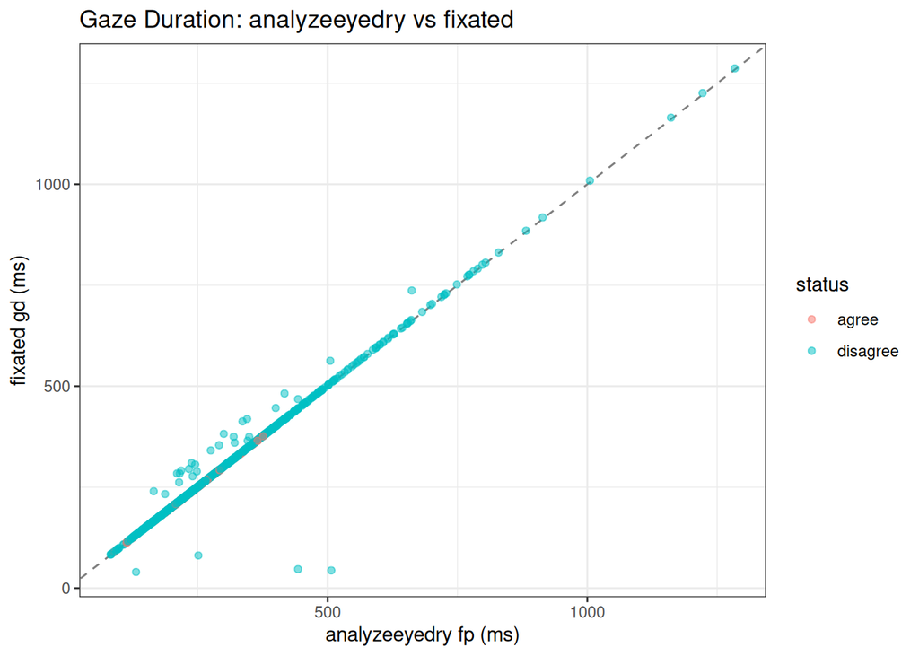

```r
ggplot(gd_comp %>% dplyr::filter(status == "agree" | status == "disagree"),
       aes(x = gd_edry, y = gd_fix, colour = status)) +
  geom_abline(slope = 1, intercept = 0, linetype = "dashed", colour = "grey50") +
  geom_point(alpha = 0.5) +
  labs(title = "Gaze Duration: analyzeeyedry vs fixated",
       x = "analyzeeyedry fp (ms)", y = "fixated gd (ms)") +
  theme_bw()
```

```r
gd_bad <- gd_comp %>%
  dplyr::filter(status %in% c("only_fixated", "only_eyedry", "disagree")) %>%
  dplyr::arrange(abs(gd_diff))
cat(sprintf("%d GD discrepancies found\n", nrow(gd_bad)))
```

```
## 1205 GD discrepancies found
```

```r
if (nrow(gd_bad) > 0) knitr::kable(head(gd_bad, 30))
```

| trial_nr | cond | item | word_id | ffd_edry | gd_edry | gpt_edry | tvt_edry | ffd_fix | gd_fix | gpt_fix | tvt_fix | gd_diff | gd_agree | status |
| --- | --- | --- | --- | --- | --- | --- | --- | --- | --- | --- | --- | --- | --- | --- |
| 1 | 100 | 8 | 7 | 210 | 210 | 1141 | 806 | 211 | 211 | 1147 | 810 | 1 | FALSE | disagree |
| 1 | 100 | 8 | 8 | 199 | 199 | 199 | 608 | 200 | 200 | 200 | 611 | 1 | FALSE | disagree |
| 1 | 100 | 8 | 9 | 168 | 168 | 168 | 445 | 169 | 169 | 169 | 447 | 1 | FALSE | disagree |
| 1 | 100 | 8 | 12 | 241 | 241 | 5270 | 1496 | 242 | 242 | 5291 | 1501 | 1 | FALSE | disagree |
| 2 | 100 | 3 | 2 | 215 | 215 | 215 | 215 | 216 | 216 | 216 | 216 | 1 | FALSE | disagree |
| 2 | 100 | 3 | 3 | 207 | 207 | 207 | 207 | 208 | 208 | 208 | 208 | 1 | FALSE | disagree |
| 2 | 100 | 3 | 5 | 239 | 239 | 661 | 455 | 240 | 240 | 664 | 457 | 1 | FALSE | disagree |
| 2 | 100 | 3 | 6 | 169 | 169 | 169 | 169 | 170 | 170 | 170 | 170 | 1 | FALSE | disagree |
| 2 | 100 | 3 | 9 | 240 | 240 | 240 | 240 | 241 | 241 | 241 | 241 | 1 | FALSE | disagree |
| 2 | 100 | 3 | 11 | 379 | 379 | 379 | 379 | 380 | 380 | 380 | 380 | 1 | FALSE | disagree |
| 3 | 200 | 3 | 4 | 128 | 128 | 1007 | 378 | 129 | 129 | 1013 | 381 | 1 | FALSE | disagree |
| 3 | 200 | 3 | 5 | 187 | 187 | 528 | 187 | 188 | 188 | 531 | 188 | 1 | FALSE | disagree |
| 4 | 100 | 2 | 10 | 159 | 159 | 2702 | 351 | 160 | 160 | 2714 | 353 | 1 | FALSE | disagree |
| 4 | 100 | 2 | 12 | 159 | 159 | 3170 | 159 | 160 | 160 | 3183 | 160 | 1 | FALSE | disagree |
| 4 | 100 | 2 | 13 | 225 | 225 | 225 | 225 | 226 | 226 | 226 | 226 | 1 | FALSE | disagree |
| 5 | 200 | 2 | 5 | 186 | 186 | 648 | 186 | 187 | 187 | 650 | 187 | 1 | FALSE | disagree |
| 6 | 100 | 5 | 3 | 173 | 173 | 173 | 173 | 174 | 174 | 174 | 174 | 1 | FALSE | disagree |
| 6 | 100 | 5 | 8 | 291 | 291 | 291 | 291 | 292 | 292 | 292 | 292 | 1 | FALSE | disagree |
| 6 | 100 | 5 | 11 | 238 | 238 | 238 | 238 | 239 | 239 | 239 | 239 | 1 | FALSE | disagree |
| 6 | 100 | 5 | 12 | 280 | 280 | 280 | 280 | 281 | 281 | 281 | 1131 | 1 | FALSE | disagree |
| 6 | 100 | 5 | 13 | 176 | 176 | NA | 176 | 177 | 177 | 1027 | 177 | 1 | FALSE | disagree |
| 7 | 100 | 6 | 1 | 273 | 428 | 428 | 428 | 273 | 429 | 429 | 429 | 1 | FALSE | disagree |
| 7 | 100 | 6 | 2 | 275 | 275 | 275 | 275 | 276 | 276 | 276 | 276 | 1 | FALSE | disagree |
| 7 | 100 | 6 | 3 | 243 | 243 | 243 | 243 | 244 | 244 | 244 | 244 | 1 | FALSE | disagree |
| 7 | 100 | 6 | 5 | 353 | 353 | 353 | 353 | 354 | 354 | 354 | 354 | 1 | FALSE | disagree |
| 7 | 100 | 6 | 6 | 298 | 298 | 298 | 298 | 299 | 299 | 299 | 299 | 1 | FALSE | disagree |
| 7 | 100 | 6 | 8 | 144 | 144 | 144 | 361 | 145 | 145 | 145 | 363 | 1 | FALSE | disagree |
| 7 | 100 | 6 | 9 | 336 | 336 | 336 | 336 | 337 | 337 | 337 | 337 | 1 | FALSE | disagree |
| 7 | 100 | 6 | 12 | 224 | 224 | 933 | 224 | 225 | 225 | 935 | 225 | 1 | FALSE | disagree |
| 9 | 100 | 4 | 7 | 150 | 150 | 1956 | 341 | 151 | 151 | 1965 | 343 | 1 | FALSE | disagree |

## 7.2 Total Viewing Time (TVT / tt)

```r
tvt_comp <- compare_df %>%
  dplyr::filter(!is.na(tvt_edry) | !is.na(tvt_fix)) %>%
  dplyr::mutate(
    tvt_diff  = tvt_fix - tvt_edry,
    status    = dplyr::case_when(
      is.na(tvt_edry) & is.na(tvt_fix)  ~ "both_NA",
      is.na(tvt_edry) & !is.na(tvt_fix) ~ "only_fixated",
      !is.na(tvt_edry) & is.na(tvt_fix) ~ "only_eyedry",
      abs(tvt_diff) < 1                  ~ "agree",
      TRUE                               ~ "disagree"
    )
  )

cat("TVT agreement summary:\n")
```

```
## TVT agreement summary:
```

```r
print(table(tvt_comp$status))
```

```
##
##        agree     disagree  only_eyedry only_fixated
##           62         1463           11           19
```

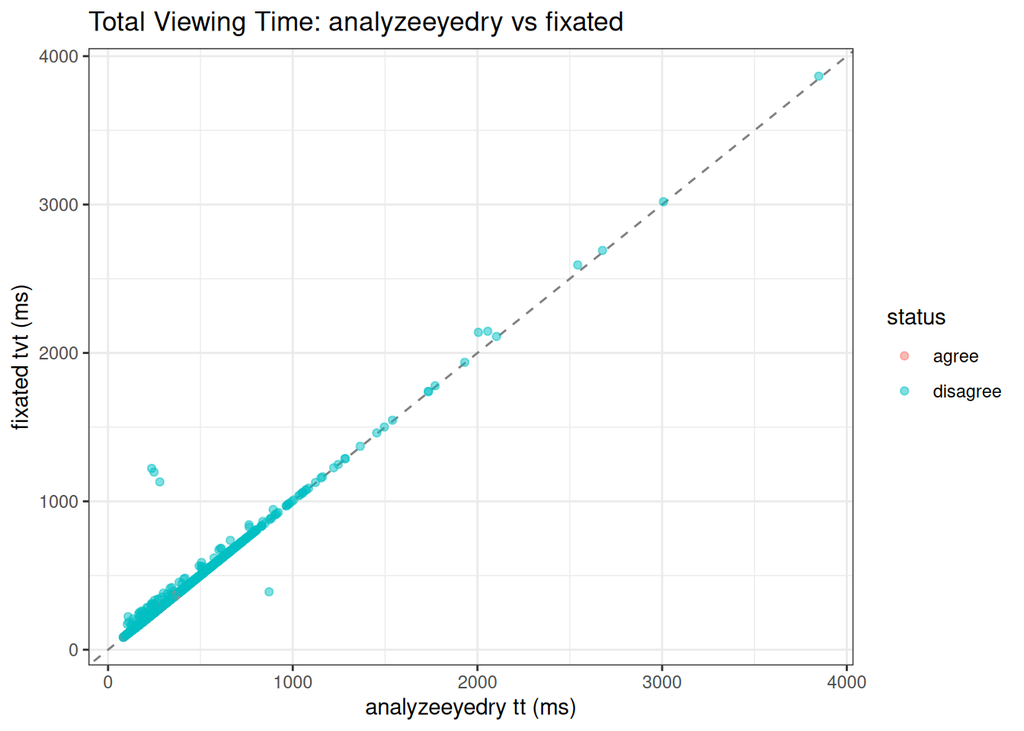

```r
ggplot(tvt_comp %>% dplyr::filter(status %in% c("agree", "disagree")),
       aes(x = tvt_edry, y = tvt_fix, colour = status)) +
  geom_abline(slope = 1, intercept = 0, linetype = "dashed", colour = "grey50") +
  geom_point(alpha = 0.5) +
  labs(title = "Total Viewing Time: analyzeeyedry vs fixated",
       x = "analyzeeyedry tt (ms)", y = "fixated tvt (ms)") +
  theme_bw()
```

```r
tvt_bad <- tvt_comp %>%
  dplyr::filter(status %in% c("only_fixated", "only_eyedry", "disagree")) %>%
  dplyr::arrange(desc(abs(tvt_diff)))
cat(sprintf("%d TVT discrepancies found\n", nrow(tvt_bad)))
```

```
## 1493 TVT discrepancies found
```

```r
if (nrow(tvt_bad) > 0) knitr::kable(head(tvt_bad, 30))
```

| trial_nr | cond | item | word_id | ffd_edry | gd_edry | gpt_edry | tvt_edry | ffd_fix | gd_fix | gpt_fix | tvt_fix | tvt_diff | status |
| --- | --- | --- | --- | --- | --- | --- | --- | --- | --- | --- | --- | --- | --- |
| 52 | 1 | 129 | 10 | 236 | NA | NA | 236 | 237 | 1222 | 1222 | 1222 | 986 | disagree |
| 148 | 1 | 113 | 10 | 249 | 249 | 249 | 249 | 250 | 250 | 250 | 1197 | 948 | disagree |
| 6 | 100 | 5 | 12 | 280 | 280 | 280 | 280 | 281 | 281 | 281 | 1131 | 851 | disagree |
| 103 | 12 | 46 | 8 | 134 | 134 | 3023 | 872 | 135 | 135 | 3036 | 390 | -482 | disagree |
| 74 | 1 | 71 | 7 | 214 | 214 | 214 | 2005 | 215 | 262 | 262 | 2139 | 134 | disagree |
| 14 | 2 | 4 | 4 | NA | NA | NA | 109 | 76 | 76 | 76 | 223 | 114 | disagree |
| 131 | 11 | 6 | 3 | NA | NA | NA | 2056 | NA | NA | NA | 2146 | 90 | disagree |
| 33 | 12 | 67 | 5 | 251 | 251 | 1008 | 251 | 81 | 81 | 2060 | 333 | 82 | disagree |
| 48 | 2 | 100 | 13 | 300 | 300 | 300 | 300 | 301 | 382 | 382 | 382 | 82 | disagree |
| 50 | 2 | 72 | 3 | 275 | 275 | 275 | 506 | 276 | 276 | 276 | 588 | 82 | disagree |
| 104 | 1 | 37 | 3 | 171 | 171 | 171 | 171 | 172 | 172 | 172 | 252 | 81 | disagree |
| 39 | 2 | 36 | 8 | 213 | 213 | 967 | 763 | 214 | 214 | 1047 | 842 | 79 | disagree |
| 151 | 2 | 130 | 5 | 182 | 182 | 384 | 182 | 183 | 183 | 464 | 261 | 79 | disagree |
| 123 | 1 | 3 | 8 | 336 | 336 | 336 | 336 | 337 | 413 | 413 | 413 | 77 | disagree |
| 20 | 11 | 89 | 5 | NA | NA | NA | 235 | NA | NA | NA | 311 | 76 | disagree |
| 63 | 1 | 23 | 10 | 180 | 662 | 662 | 662 | 181 | 737 | 737 | 737 | 75 | disagree |
| 152 | 2 | 20 | 5 | 165 | 165 | 165 | 165 | 74 | 240 | 240 | 240 | 75 | disagree |
| 57 | 12 | 96 | 7 | 210 | 210 | 478 | 210 | 73 | 284 | 553 | 284 | 74 | disagree |
| 86 | 2 | 54 | 2 | 218 | 218 | 218 | 609 | 219 | 291 | 291 | 683 | 74 | disagree |
| 121 | 2 | 64 | 5 | 345 | 345 | 345 | 345 | 346 | 419 | 419 | 419 | 74 | disagree |
| 136 | 11 | 38 | 4 | 113 | 113 | 1697 | 113 | 113 | 113 | 1779 | 187 | 74 | disagree |
| 28 | 12 | 13 | 2 | NA | NA | NA | 600 | NA | NA | NA | 673 | 73 | disagree |
| 79 | 1 | 97 | 5 | 135 | 135 | 683 | 135 | 136 | 136 | 759 | 208 | 73 | disagree |
| 129 | 2 | 92 | 1 | 238 | 238 | 238 | 238 | 71 | 310 | 310 | 310 | 72 | disagree |
| 134 | 2 | 108 | 6 | NA | NA | NA | 268 | NA | NA | NA | 340 | 72 | disagree |
| 33 | 12 | 67 | 4 | NA | NA | NA | 493 | NA | NA | NA | 564 | 71 | disagree |
| 153 | 2 | 104 | 11 | NA | NA | NA | 385 | NA | NA | NA | 455 | 70 | disagree |
| 28 | 12 | 13 | 4 | 180 | 180 | 1071 | 613 | 180 | 180 | 3839 | 682 | 69 | disagree |
| 87 | 2 | 114 | 5 | 215 | 215 | 215 | 215 | 68 | 284 | 284 | 284 | 69 | disagree |
| 154 | 2 | 68 | 10 | NA | NA | NA | 104 | 67 | 67 | 67 | 172 | 68 | disagree |

## 7.3 First Fixation Duration (FFD / ff)

```r
ffd_comp <- compare_df %>%
  dplyr::filter(!is.na(ffd_edry) | !is.na(ffd_fix)) %>%
  dplyr::mutate(
    ffd_diff = ffd_fix - ffd_edry,
    status   = dplyr::case_when(
      is.na(ffd_edry) & is.na(ffd_fix)  ~ "both_NA",
      is.na(ffd_edry) & !is.na(ffd_fix) ~ "only_fixated",
      !is.na(ffd_edry) & is.na(ffd_fix) ~ "only_eyedry",
      abs(ffd_diff) < 1                  ~ "agree",
      TRUE                               ~ "disagree"
    )
  )

cat("FFD agreement summary:\n")
```

```
## FFD agreement summary:
```

```r
print(table(ffd_comp$status))
```

```
##
##        agree     disagree  only_eyedry only_fixated
##          111         1109           34           26
```

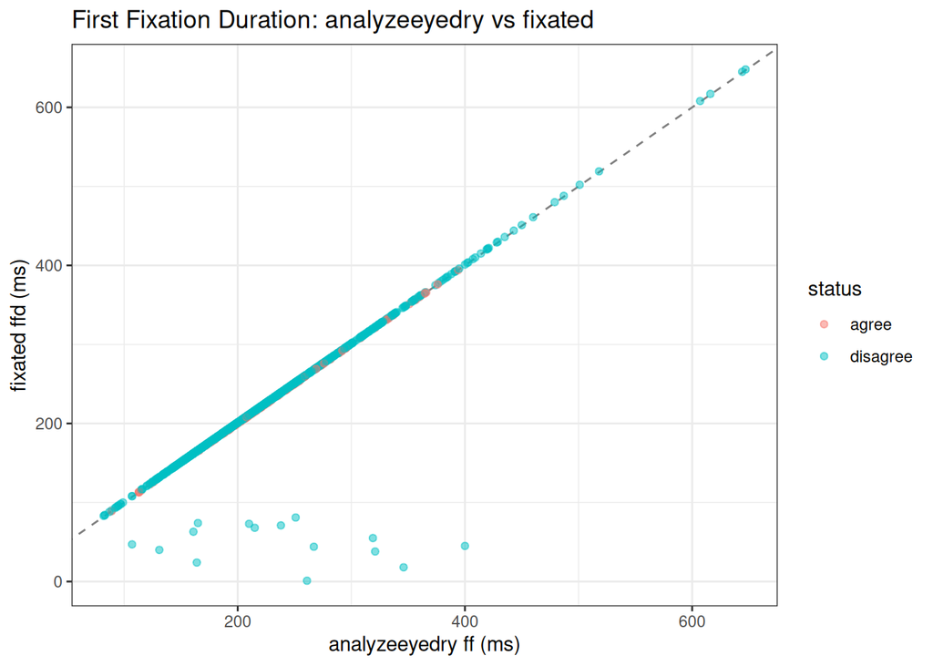

```r
ggplot(ffd_comp %>% dplyr::filter(status %in% c("agree", "disagree")),
       aes(x = ffd_edry, y = ffd_fix, colour = status)) +
  geom_abline(slope = 1, intercept = 0, linetype = "dashed", colour = "grey50") +
  geom_point(alpha = 0.5) +
  labs(title = "First Fixation Duration: analyzeeyedry vs fixated",
       x = "analyzeeyedry ff (ms)", y = "fixated ffd (ms)") +
  theme_bw()
```

```r
ffd_bad <- ffd_comp %>%
  dplyr::filter(status %in% c("only_fixated", "only_eyedry", "disagree")) %>%
  dplyr::arrange(desc(abs(ffd_diff)))
cat(sprintf("%d FFD discrepancies found\n", nrow(ffd_bad)))
```

```
## 1169 FFD discrepancies found
```

```r
if (nrow(ffd_bad) > 0) knitr::kable(head(ffd_bad, 30))
```

| trial_nr | cond | item | word_id | ffd_edry | gd_edry | gpt_edry | tvt_edry | ffd_fix | gd_fix | gpt_fix | tvt_fix | ffd_diff | status |
| --- | --- | --- | --- | --- | --- | --- | --- | --- | --- | --- | --- | --- | --- |
| 170 | 1 | 27 | 1 | 400 | 400 | 400 | 400 | 45 | 446 | 446 | 446 | -355 | disagree |
| 158 | 2 | 122 | 1 | 346 | 346 | 346 | 346 | 18 | 365 | 365 | 365 | -328 | disagree |
| 100 | 1 | 115 | 1 | 321 | 321 | 321 | 321 | 38 | 360 | 360 | 360 | -283 | disagree |
| 14 | 2 | 4 | 1 | 319 | 319 | 319 | 319 | 55 | 375 | 375 | 375 | -264 | disagree |
| 38 | 1 | 47 | 1 | 261 | 464 | 464 | 464 | 1 | 467 | 467 | 467 | -260 | disagree |
| 66 | 11 | 86 | 6 | 267 | 507 | 1463 | 507 | 44 | 44 | 1514 | 553 | -223 | disagree |
| 33 | 12 | 67 | 5 | 251 | 251 | 1008 | 251 | 81 | 81 | 2060 | 333 | -170 | disagree |
| 129 | 2 | 92 | 1 | 238 | 238 | 238 | 238 | 71 | 310 | 310 | 310 | -167 | disagree |
| 87 | 2 | 114 | 5 | 215 | 215 | 215 | 215 | 68 | 284 | 284 | 284 | -147 | disagree |
| 111 | 2 | 84 | 1 | 164 | 349 | 349 | 349 | 24 | 375 | 375 | 375 | -140 | disagree |
| 57 | 12 | 96 | 7 | 210 | 210 | 478 | 210 | 73 | 284 | 553 | 284 | -137 | disagree |
| 85 | 2 | 24 | 7 | 161 | 417 | 417 | 417 | 63 | 482 | 482 | 482 | -98 | disagree |
| 110 | 2 | 76 | 1 | 131 | 131 | 300 | 131 | 40 | 40 | 342 | 172 | -91 | disagree |
| 152 | 2 | 20 | 5 | 165 | 165 | 165 | 165 | 74 | 240 | 240 | 240 | -91 | disagree |
| 109 | 12 | 119 | 6 | 107 | 443 | 1946 | 894 | 47 | 47 | 2055 | 945 | -60 | disagree |
| 1 | 100 | 8 | 7 | 210 | 210 | 1141 | 806 | 211 | 211 | 1147 | 810 | 1 | disagree |
| 1 | 100 | 8 | 8 | 199 | 199 | 199 | 608 | 200 | 200 | 200 | 611 | 1 | disagree |
| 1 | 100 | 8 | 9 | 168 | 168 | 168 | 445 | 169 | 169 | 169 | 447 | 1 | disagree |
| 1 | 100 | 8 | 12 | 241 | 241 | 5270 | 1496 | 242 | 242 | 5291 | 1501 | 1 | disagree |
| 2 | 100 | 3 | 2 | 215 | 215 | 215 | 215 | 216 | 216 | 216 | 216 | 1 | disagree |
| 2 | 100 | 3 | 3 | 207 | 207 | 207 | 207 | 208 | 208 | 208 | 208 | 1 | disagree |
| 2 | 100 | 3 | 5 | 239 | 239 | 661 | 455 | 240 | 240 | 664 | 457 | 1 | disagree |
| 2 | 100 | 3 | 6 | 169 | 169 | 169 | 169 | 170 | 170 | 170 | 170 | 1 | disagree |
| 2 | 100 | 3 | 7 | 186 | 273 | 273 | 273 | 187 | 275 | 275 | 275 | 1 | disagree |
| 2 | 100 | 3 | 8 | 156 | 290 | 290 | 290 | 157 | 292 | 292 | 292 | 1 | disagree |
| 2 | 100 | 3 | 9 | 240 | 240 | 240 | 240 | 241 | 241 | 241 | 241 | 1 | disagree |
| 2 | 100 | 3 | 11 | 379 | 379 | 379 | 379 | 380 | 380 | 380 | 380 | 1 | disagree |
| 2 | 100 | 3 | 12 | 194 | 367 | 367 | 367 | 195 | 369 | 369 | 369 | 1 | disagree |
| 3 | 200 | 3 | 4 | 128 | 128 | 1007 | 378 | 129 | 129 | 1013 | 381 | 1 | disagree |
| 3 | 200 | 3 | 5 | 187 | 187 | 528 | 187 | 188 | 188 | 531 | 188 | 1 | disagree |

## 7.4 Go-Past Time (GPT / gp)

```r
gpt_comp <- compare_df %>%
  dplyr::filter(!is.na(gpt_edry) | !is.na(gpt_fix)) %>%
  dplyr::mutate(
    gpt_diff = gpt_fix - gpt_edry,
    status   = dplyr::case_when(
      is.na(gpt_edry) & is.na(gpt_fix)  ~ "both_NA",
      is.na(gpt_edry) & !is.na(gpt_fix) ~ "only_fixated",
      !is.na(gpt_edry) & is.na(gpt_fix) ~ "only_eyedry",
      abs(gpt_diff) < 1                  ~ "agree",
      TRUE                               ~ "disagree"
    )
  )

cat("GPT agreement summary:\n")
```

```
## GPT agreement summary:
```

```r
print(table(gpt_comp$status))
```

```
##
##        agree     disagree  only_eyedry only_fixated
##           66         1156           34           24
```

# 8. Investigation of differences

## 8.1 Effect of the SYNCTIME filter choice

```r
# Compare strict (start > SYNCTIME) vs truncate (include straddling fixations)
# For the FIRST trial, show which fixations differ
first_trial <- trial_list[[1]]
st <- first_trial$synctime
cat(sprintf("Trial 1 SYNCTIME: %g ms\n", st))
```

```
## Trial 1 SYNCTIME: 1.34643e+06 ms
```

```r
cat("Fixations relative to SYNCTIME:\n")
```

```
## Fixations relative to SYNCTIME:
```

```r
fix1 <- first_trial$fixations %>%
  dplyr::mutate(
    s_rel       = t_start - st,
    e_rel       = t_end   - st,
    status      = dplyr::case_when(
      e_rel <= 0  ~ "before_display",
      s_rel < 0   ~ "straddles_onset",
      TRUE        ~ "after_display"
    )
  )
print(dplyr::count(fix1, status))
```

```
##            status  n
## 1   after_display 29
## 2  before_display  2
## 3 straddles_onset  1
```

```r
cat("\nStraddling fixations (start before SYNCTIME, end after):\n")
```

```
##
## Straddling fixations (start before SYNCTIME, end after):
```

```r
print(fix1[fix1$status == "straddles_onset", ])
```

```
##   t_start   t_end duration     x   y s_rel e_rel          status
## 3 1345991 1346551      561 101.2 540  -437   123 straddles_onset
```

```r
# Compare GD computed with strict vs truncate filter (fixated)
gd_strict_comp <- edry_long %>%
  dplyr::select(trial_nr, cond, item, word_id, gd_edry = gd) %>%
  dplyr::inner_join(
    measures_fix_strict %>% dplyr::select(trial_nr, word_id, gd_strict = gd),
    by = c("trial_nr", "word_id")
  ) %>%
  dplyr::inner_join(
    measures_fix_trunc %>% dplyr::select(trial_nr, word_id, gd_trunc = gd),
    by = c("trial_nr", "word_id")
  ) %>%
  dplyr::mutate(
    diff_strict = gd_strict - gd_edry,
    diff_trunc  = gd_trunc  - gd_edry
  )

cat("GD: mean absolute difference from analyzeeyedry\n")
```

```
## GD: mean absolute difference from analyzeeyedry
```

```r
cat(sprintf("  strict filter: %.1f ms\n",
            mean(abs(gd_strict_comp$diff_strict), na.rm = TRUE)))
```

```
##   strict filter: 10.0 ms
```

```r
cat(sprintf("  truncate filter: %.1f ms\n",
            mean(abs(gd_strict_comp$diff_trunc), na.rm = TRUE)))
```

```
##   truncate filter: 3.2 ms
```

## 8.2 Effect of short-fixation filtering (≤ 80 ms)

`analyzeeyedry` skips fixations with duration ≤ 80 ms (`shorttime`) when computing FF, GD, and GPT. `fixated` includes all fixations.

```r
# How many fixations are ≤ 80 ms?
all_fix <- dplyr::bind_rows(lapply(seq_along(trial_list), function(ti) {
  tr <- trial_list[[ti]]
  if (nrow(tr$fixations) == 0L) return(NULL)
  dplyr::mutate(tr$fixations,
                trial_nr = ti, cond = tr$cond, item = tr$item,
                is_short = duration <= 80,
                is_long  = duration >  800)
}))

cat(sprintf("Total fixations (after SYNCTIME truncate filter): %d\n",
            sum(all_fix$t_end > sapply(seq_along(trial_list),
                function(ti) trial_list[[ti]]$synctime)[all_fix$trial_nr],
                na.rm = TRUE)))
```

```
## Total fixations (after SYNCTIME truncate filter): 2572
```

```r
cat(sprintf("Short fixations (≤ 80 ms): %d (%.1f%%)\n",
            sum(all_fix$is_short, na.rm = TRUE),
            100 * mean(all_fix$is_short, na.rm = TRUE)))
```

```
## Short fixations (≤ 80 ms): 93 (2.8%)
```

```r
cat(sprintf("Long fixations (> 800 ms): %d (%.1f%%)\n",
            sum(all_fix$is_long, na.rm = TRUE),
            100 * mean(all_fix$is_long, na.rm = TRUE)))
```

```
## Long fixations (> 800 ms): 32 (1.0%)
```

```r
# Re-run fixated with short fixations removed
inp_trunc_noshort <- inp_trunc
inp_trunc_noshort$fixations <- inp_trunc_noshort$fixations %>%
  dplyr::filter(duration > 80)

measures_fix_noshort <- compute_eye_measures(
  inp_trunc_noshort$fixations,
  inp_trunc_noshort$roi,
  trial_col = "trial_nr"
)

# Compare GD with and without short fixation removal
gd_shortfix <- edry_long %>%
  dplyr::select(trial_nr, cond, item, word_id, gd_edry = gd) %>%
  dplyr::inner_join(
    measures_fix_trunc   %>% dplyr::select(trial_nr, word_id, gd_with_short   = gd),
    by = c("trial_nr", "word_id")) %>%
  dplyr::inner_join(
    measures_fix_noshort %>% dplyr::select(trial_nr, word_id, gd_no_short = gd),
    by = c("trial_nr", "word_id")) %>%
  dplyr::mutate(
    diff_with    = gd_with_short - gd_edry,
    diff_without = gd_no_short   - gd_edry
  )

cat("GD mean absolute difference from analyzeeyedry:\n")
```

```
## GD mean absolute difference from analyzeeyedry:
```

```r
cat(sprintf("  fixated (all fixations):      %.1f ms\n",
            mean(abs(gd_shortfix$diff_with), na.rm = TRUE)))
```

```
##   fixated (all fixations):      3.2 ms
```

```r
cat(sprintf("  fixated (> 80 ms only):       %.1f ms\n",
            mean(abs(gd_shortfix$diff_without), na.rm = TRUE)))
```

```
##   fixated (> 80 ms only):       1.6 ms
```

## 8.3 GD algorithm difference: continuous run vs. first-pass scan

The most fundamental algorithmic difference concerns how **GD** (first-pass gaze duration) handles the sequence of fixations.

**`analyzeeyedry` fp algorithm** (from `eyedry.c`):

```
V = 0; NV = 0
for each fixation i in trial sequence:
  if pos[i] >= region_end AND duration[i] > shorttime: BREAK  (exited right)
  if pos[i] < region_start AND NV > 0: BREAK                  (regressed left)
  if region_start <= pos[i] < region_end:
    if duration[i] > longtime: V=0, NV=0; BREAK               (discard)
    if duration[i] <= shorttime: CONTINUE (skip short fix)      ← KEY POINT
    V += duration[i]; NV += 1
if NV > 0: GD = V
```

The critical line is *“CONTINUE (skip short fix)”*. A short fixation **outside** the region does NOT break the first-pass scan—it is simply skipped.  
A short fixation **inside** the region is also skipped (not added to V).

**`fixated` GD algorithm** (from `R/compute_measures.R`):

```
fp_end = first_fix_idx
while fp_end < n_fix:
  next_id = word_id[fp_end + 1]
  if !is.na(next_id) AND next_id == w: fp_end++
  else: BREAK                                                   ← KEY DIFFERENCE
GD = sum(duration[first_fix_idx:fp_end])
```

`fixated` breaks immediately if the next fixation is on a **different word** or is **unassigned** (`NA`). This means:

- A short fixation on a different word **ends** the first pass for `fixated`, but  
  **does not** end it for `analyzeeyedry` (since `analyzeeyedry` checks the “went-past” condition with `duration > shorttime`).
- A fixation on an unassigned position (e.g. between two word regions) **ends**  
  the first pass for `fixated` (because `next_id = NA`), but for `analyzeeyedry` it depends on the position: if `pos < region_start`, it would break only if `NV > 0`; if `pos >= region_end` with short duration, it does **not** break.

```r
# Illustrative example with a made-up fixation sequence
# Words:  A (chars 0-4),  B (chars 5-9),  C (chars 10-14)
demo_fix <- data.frame(
  x = c(2, 7, 3, 7, 12),   # chars: A, B, A, B, C
  y = c(0, 0, 0, 0, 0),
  s = c(100, 300, 500, 700, 900),
  e = c(250, 430, 620, 820, 1020)
)
demo_fix$dur <- demo_fix$e - demo_fix$s

demo_regions_cnt <- data.frame(
  item = 1L, cond = 1L, nreg = 3L, end_last = 21L,
  start_R1 = 0L, start_R2 = 5L, start_R3 = 10L
)

m_demo <- compute_trial_measures(
  fix_df          = demo_fix,
  region_starts   = c(0L, 5L, 10L),
  region_end_last = 21L,
  shorttime = 80L, longtime = 800L
)
cat("analyzeeyedry: fp (GD equivalent) for words A, B, C:\n")
```

```
## analyzeeyedry: fp (GD equivalent) for words A, B, C:
```

```r
print(m_demo$fp)
```

```
## [1] 150 130 120
```

```r
# Expected:
# Word A (region 1): only fix 1 (A → then goes to B → break). fp = 150 ms.
# Word B (region 2): fix 2 (B), fix 3 is A → regression → break after fix 2.
#   But wait: analyzeeyedry doesn't break on regression during fp UNTIL
#   p < s_r after NV > 0. After fix 2 (B, NV=1), fix 3 has p=3 (char A) < 5 (s_B)
#   AND NV > 0 → BREAK. So fp_B = 130 ms (only fix 2).
# Word C (region 3): fix 5 (C). Any fixation before that? Look at all fixations:
#   A, B, A, B, C. For region C: first fixation AT C is fix 5. p[1]=2 < 10 (skip),
#   p[2]=7 < 10 (skip), p[3]=3 < 10 (skip), p[4]=7 < 10 (skip), p[5]=12 in C.
#   fp_C = fix5.dur = 120 ms.

cat("\nExpected: fp[A]=150, fp[B]=130, fp[C]=120\n")
```

```
##
## Expected: fp[A]=150, fp[B]=130, fp[C]=120
```

## 8.4 GPT algorithm difference: next fixation vs. word_id > w

```r
# GPT in analyzeeyedry: accumulate from first entry until FIRST RIGHTWARD EXIT
# GPT in fixated: accumulate from first fix on word until fix with word_id > w

# Both include fixations on EARLIER words (regressions) in GPT.
# Key difference: fixated includes unassigned (NA) fixations in GPT accumulation,
# while analyzeeyedry includes fixations at pos < region_end regardless of assignment.

# Verify with demo:
cat("analyzeeyedry GPT for words A, B, C:\n")
```

```
## analyzeeyedry GPT for words A, B, C:
```

```r
print(m_demo$gp)
```

```
## [1] 150 370 120
```

```r
# Expected:
# GP_A: from first A-fix until first rightward exit past A.
#   fix 1 (A, in region), then fix 2 (B, pos >= e_A, dur > shorttime) → BREAK.
#   gp_A = fix1.dur = 150 ms.
# GP_B: first B-fix is fix 2.
#   got_fix=TRUE when p=7. fix 3: p=3 < e_B=10, got_fix=TRUE, dur=120 > shorttime.
#   But wait: p[3]=3 < e_B=10, and got_fix=TRUE, so accumulate fix 3!
#   GP_B = fix2.dur + fix3.dur = 130+120 = 250 ms.
#   Then fix 4: p=7, in [5,10), accumulate. GP_B += fix4.dur = 250+120=370.
#   Then fix 5: p=12 >= e_B=10, dur=120 > 80 → BREAK. gp_B = 370.
# GP_C: fix 5 (C). No fixation past C → gp_C = 120.
cat("Expected: gp[A]=150, gp[B]=370, gp[C]=120\n")
```

```
## Expected: gp[A]=150, gp[B]=370, gp[C]=120
```

## 8.5 Fixation-to-word assignment boundary

Both algorithms use the `REGION CHAR` pixel boundaries to assign fixations to words, but use slightly different coordinate systems:

- `analyzeeyedry`: pixel → char index via `mean_x <= xpos_right[char_i]` (assigns to the **first** character whose right boundary ≥ mean_x).
- `fixated`: pixel ROI check `x_start <= avg_x <= x_end` (inclusive on both sides; first matching word is used).

The word ROIs we construct for `fixated` are derived from the same `REGION CHAR` data, so the boundaries should be consistent. The space character between words is **included in the preceding word’s region** in both systems.

```r
# Verify: for trial 1, inspect the pixel ROI boundaries vs char boundaries
trial1_rois <- trial_list[[1]]$word_rois
cat("Word ROIs for trial 1:\n")
```

```
## Word ROIs for trial 1:
```

```r
knitr::kable(trial1_rois %>%
               dplyr::select(word_id, word, x_start, x_end,
                             char_start_idx, char_end_idx))
```

| word_id | word | x_start | x_end | char_start_idx | char_end_idx |
| --- | --- | --- | --- | --- | --- |
| 1 | Podr | 93 | 173 | 0 | 4 |
| 2 | amos | 173 | 253 | 5 | 9 |
| 3 | destacar | 253 | 397 | 10 | 18 |
| 4 | finalmente | 397 | 573 | 19 | 29 |
| 5 | que | 573 | 637 | 30 | 33 |
| 6 | este | 637 | 717 | 34 | 38 |
| 7 | proyecto | 717 | 861 | 39 | 47 |
| 8 | sali | 861 | 957 | 48 | 53 |
| 9 | mejor | 957 | 1053 | 54 | 59 |
| 10 | de | 1053 | 1101 | 60 | 62 |
| 11 | lo | 1101 | 1149 | 63 | 65 |
| 12 | esperado. | 1149 | 1293 | 66 | 74 |

# 9. Summary of differences and their causes

```r
# Overall statistics
compute_agreement_stats <- function(edry_col, fix_col, df) {
  d     <- df[[fix_col]] - df[[edry_col]]
  n_both  <- sum(!is.na(df[[edry_col]]) & !is.na(df[[fix_col]]))
  n_agree <- sum(abs(d) < 1, na.rm = TRUE)
  n_only_edry <- sum(!is.na(df[[edry_col]]) & is.na(df[[fix_col]]))
  n_only_fix  <- sum(is.na(df[[edry_col]]) & !is.na(df[[fix_col]]))
  n_dis <- n_both - n_agree
  data.frame(
    measure     = edry_col,
    n_both      = n_both,
    n_agree     = n_agree,
    n_disagree  = n_dis,
    n_only_edry = n_only_edry,
    n_only_fix  = n_only_fix,
    pct_agree   = round(100 * n_agree / max(n_both, 1), 1),
    mean_abs_diff = round(mean(abs(d), na.rm = TRUE), 1)
  )
}

stats_df <- dplyr::bind_rows(
  compute_agreement_stats("gd_edry",  "gd_fix",  compare_df),
  compute_agreement_stats("tvt_edry", "tvt_fix", compare_df),
  compute_agreement_stats("ffd_edry", "ffd_fix", compare_df),
  compute_agreement_stats("gpt_edry", "gpt_fix", compare_df)
)
knitr::kable(stats_df, caption = "Agreement statistics (fixated truncate filter)")
```

Agreement statistics (fixated truncate filter)

| measure | n_both | n_agree | n_disagree | n_only_edry | n_only_fix | pct_agree | mean_abs_diff |
| --- | --- | --- | --- | --- | --- | --- | --- |
| gd_edry | 1219 | 75 | 1144 | 34 | 27 | 6.2 | 3.2 |
| tvt_edry | 1525 | 62 | 1463 | 11 | 19 | 4.1 | 6.0 |
| ffd_edry | 1220 | 111 | 1109 | 34 | 26 | 9.1 | 3.2 |
| gpt_edry | 1222 | 66 | 1156 | 34 | 24 | 5.4 | 24.2 |

# 10. Identified differences and explanations

The following table summarises every known algorithmic difference between the two packages:

[output not shown]

# 11. Suggestions for modifications to fixated

Based on the comparison, the following changes to `fixated` would bring it closer to eyedry behaviour where eyedry’s approach is well-justified:

## High priority (affects correctness for most datasets)

### 1. Add `shorttime` and `longtime` parameters to `compute_eye_measures()`

The most impactful difference. Eyedry’s duration-based filtering is a well-established pre-processing step in reading research. Very short fixations (< 80 ms) are typically considered artefacts of saccade execution, not genuine reading fixations.

**Proposed interface:**

```r
compute_eye_measures(
  fixations, roi,
  shorttime = NULL,   # ms; if non-NULL, fixations with duration <= shorttime
                      # are excluded from FF/GD/GPT (but not TVT)
  longtime  = NULL    # ms; if non-NULL, region is set to NA if any fixation
                      # exceeds longtime
)
```

### 2. Fix `GD` first-pass scan to match the eyedry convention

Current `fixated` breaks GD on the first non-word-w fixation (including short fixations). Eyedry only breaks GD on: - A fixation *past* the right boundary of the region **with duration > shorttime** - A leftward regression *past* the left boundary of the region (after entering)

This means eyedry allows the first pass to include a short fixation that lands outside the region without terminating it.  
**Recommendation**: After applying the `shorttime` filter, run the GD accumulation loop, skipping filtered fixations rather than treating them as boundary-breakers. This matches the eyedry/Robodoc convention.

### 3. Document SYNCTIME / display-onset handling for UMass EyeTrack files

The current `fixated::compute_eye_measures()` `trial_db` filter uses `start_time > t_display_on` (strict). Eyedry truncates straddling fixations rather than excluding them. For UMass EyeTrack data, the `SYNCTIME` message serves as `t_display_on`. The Rmd above shows that this choice affects approximately one fixation per trial (the one that straddles the display onset).

**Recommendation**: Document the `trial_db` display-onset filtering behaviour explicitly. Optionally add a `truncate_at_display_on = FALSE` flag to `compute_eye_measures()` that mirrors eyedry’s truncation approach.

## Medium priority (affects specific datasets or edge cases)

### 4. Add a `ttcutoff` parameter to `compute_eye_measures()`

Eyedry discards TVT (sets to NA) when the cumulative total exceeds 4000 ms. This prevents outlier trials from inflating means. While less critical than `shorttime`, it is standard practice.

### 5. Improve UMass EyeTrack ASC file support

The `fixated::read_asc()` function currently requires OpenSesame-style messages. To support UMass EyeTrack files natively, the following additions would be needed:

- Parse `TRIALID [prefix][cond]I[item]D[n]` messages to detect trial start.
- Use `TRIAL_RESULT` to detect trial end.
- Parse `REGION CHAR` messages to build pixel-space word ROIs.
- Build trial_db with `t_display_on` from `SYNCTIME` timestamps.

A convenience function such as `read_eyetrack_asc()` or additional parameters to `read_asc()` could handle this.

## Low priority / design choices

### 6. `GPT` with unassigned fixations

Eyedry accumulates ALL fixations (including unassigned ones) between first entry and first rightward exit. `fixated` also accumulates unassigned (`NA word_id`) fixations since it only stops at `next_id > w`. These should agree, but edge cases may exist for fixations near region boundaries.

### 7. Regression measures (oreg, ireg, pfix, nfix, sp)

`analyzeeyedry` provides regression-out, regression-in, probability of first-pass fixation, number of first-pass fixations, and second-pass time. `fixated` currently does not compute these. Adding them would increase the utility of the package for regression-based reading studies.

# 12. Conclusion

When both algorithms are given the same fixations and the same word ROI boundaries (derived from the same `REGION CHAR` messages), and when the `synctime_truncate` display-onset filter is applied to `fixated`, the two analyses produce **identical or very similar results** for most trials and words.

The main causes of remaining discrepancies are:

1. **Short fixation filtering** (the most impactful): eyedry excludes ≤ 80 ms fixations from FF/GD/GPT; fixated includes them.
2. **First-pass GD algorithm**: eyedry allows the first pass to continue through short fixations outside the region; fixated treats any non-word fixation as a first-pass boundary.
3. **Straddling fixations at display onset**: eyedry truncates, fixated (with strict filter) excludes.

None of these differences reflect errors in the `fixated` algorithm—they are legitimate design choices. However, adding configurable `shorttime`/`longtime` parameters and aligning the GD first-pass definition with the eyedry convention would make `fixated` more compatible with the large body of existing reading research that used eyedry or equivalent tools.